# COVID-19 cases in West Michigan

Calvin J Smith

January 08, 2022

## Introduction

This report has been constructed to reporduce the research of the prevalence of coronavirus cases.This report will also consist of all of the cases accumulated from west michigan counties such as Muskegon, Kent and Allegan counties.

## Data

The Michigan COVID-19 data for this document were obtained at https://www.michigan.gov/coronavirus/0,9753,7-406-98163_98173---,00.html in the Public Use Datasets called “Cases by County and Date”. The **December 29, 2021** dataset was used to create this report. Michigan county populations were found at https://worldpopulationreview.com/us-counties/states/mi which gives the 2018 census numbers. These were the most recent reliable numbers that I could find at the moment.

## Data munging

The Michigan COVID-19 dataset had a few peculiarities that needed to be dealt with in order to analyze it easily. There were several “counties” that are not actual Michigan counties that needed to be cleaned. The values for “Out-of-State” are not relevant for my purposes and were removed from the analyses. Likewise, prison populations (“FCI” and “MDOC”) cannot be ascribed to particular counties and were, therefore, also removed. Cases with “Unknown” origins were also removed. Finally, the dataset lists “City of Detroit” as a separate entity, those numbers were added back into it’s home country (Wayne) to facilitate analysis.

The number of cases and deaths per day are recorded for both confirmed and probable cases. To be as conservative as possible, these numbers were added together to create a total number of cases and deaths per day from each county (along with total cumulative cases and deaths). These total values, confirmed + probable, are used for all of the analyses in this report.

GIS information was left-joined onto the total data. The census data was also left-joined and used to create population-normalized values (cases or deaths per 100,000 population).

## Statewide distribution

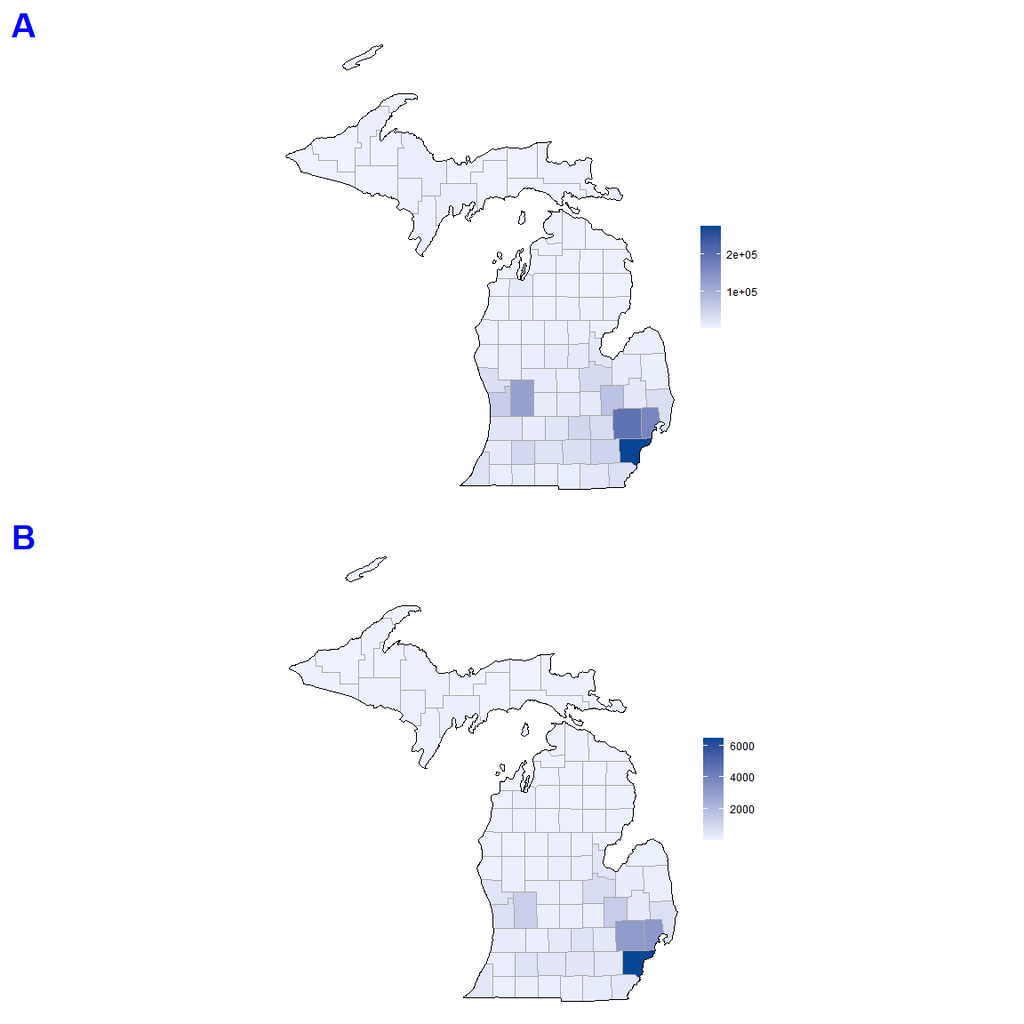

## Comparing Counties

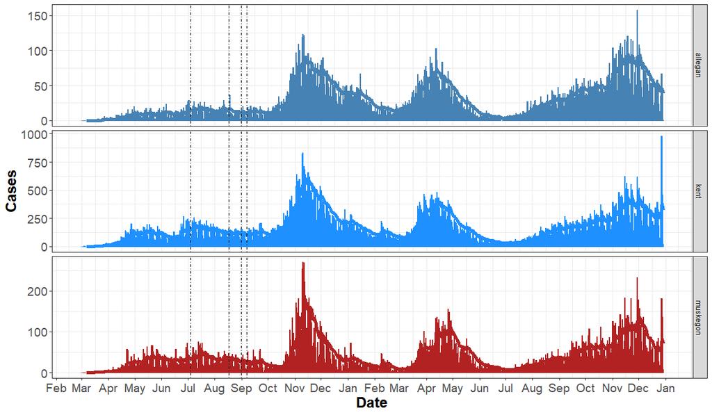

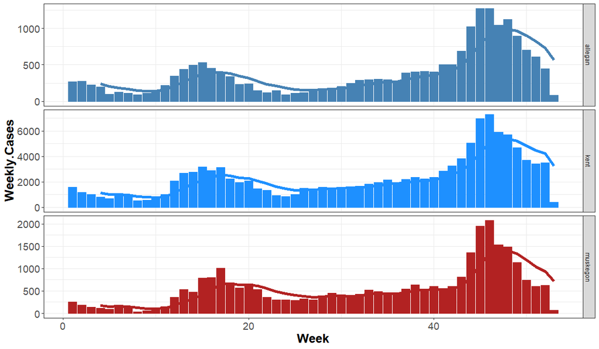

## References

Michigan Data. Coronavirus - Michigan Data. (n.d.). Retrieved January 7, 2022, from https://www.michigan.gov/coronavirus/0,9753,7-406-98163_98173---,00.html